# Apollo_case_study

### Normality and Variance Tests

#### Shapiro-Wilk’s test

We will test the null hypothesis

> $H_0:$ Viral Load follows normal distribution

against the alternative hypothesis

> $H_a:$ Viral Load doesn't follow normal distribution

```python
from scipy.stats import shapiro
w, p_value = shapiro(df['viral load'])
print('The p-value is', p_value)
if p_value > 0.05:
     print('Since p_value > 0.05 we fail to reject the null hypothesis.')
else:
     print('Since p_value < 0.05 we reject the null hypothesis.')
```

```
The p-value is 2.689460598048754e-05
Since p_value < 0.05 we reject the null hypothesis.
```

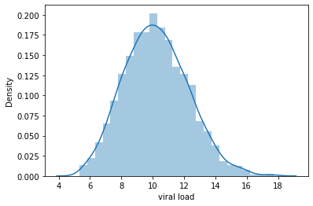

```python
sns.distplot(df['viral load'])
```

#### K-S Test

- **Null Hypothesis** ( $H_0):$ viral load of male and female has Distribution..
- **Alternative Hypothesis** ($H_a):$ viral load of male and female has **Different Distribution** .

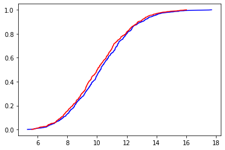

```python
from statsmodels.distributions.empirical_distribution import ECDF
e1 = ECDF(viral_load_men)
e2 = ECDF(viral_load_female)
plt.figure()
plt.plot(e1.x, e1.y, c='b')
plt.plot(e2.x, e2.y, c='r')
```

### Levene’s test

We will test the null hypothesis

> $H_0$: viral load variances are equal in both groups

against the alternative hypothesis

> $H_a$: viral load variances are differnt

```python
from scipy.stats import levene
statistic, p_value = levene( viral_load_female,viral_load_men)
# find the p-value
print('The p-value is', p_value)
if p_value > 0.05:
     print('Since p_value > 0.05 we fail to reject the null hypothesis.')
else:
     print('Since p_value < 0.05 we reject the null hypothesis.')
```

```
The p-value is 0.8559762854937386
Since p_value > 0.05 we fail to reject the null hypothesis.
```

- Since p-value is grater then 0.5, we fail to reject null hypothesis, So the viral load variances are equal in both groups

## Two sample ttest

- **Problem Statement** : Prove (or disprove) with statistical evidence that the viral load of females is different from that of males
- **Null Hypothesis** ( $H_0):$ Average viral load of male and female is same.
- **Alternative Hypothesis** ($H_a):$ Average viral load of male and female is different.
- $\mu_1$ - Average Viral Load of Female
- $\mu_2$- Average Viral Load of Male

> $H_0: \mu_1 = \mu_2$

> $H_a: \mu_1 != \mu_2$

```python
viral_load_female.mean()
```

```
10.126072507552863
```

```python
viral_load_men.mean()
```

```
10.31436555891238
```

```python
from scipy import stats
stats,p_value=stats.ttest_ind(viral_load_female,viral_load_men,equal_var = True)
print('The p-value is', p_value)
if p_value > 0.05:
     print('Since p_value > 0.05 we fail to reject the null hypothesis.')
else:
     print('Since p_value < 0.05 we reject the null hypothesis.')
```

```
The p-value is 0.09277758646164116
Since p_value > 0.05 we fail to reject the null hypothesis.
```

### Since p-value is greater then 0.05, we fail to reject the null hypothesis, which means that the average viral load of males and females is same

# Chi square test

> - H0: Smokers and Region are independent
> - Ha: Smoker and Region are dependant
> - **Problem Statement** :Is the proportion of smoking significantly different across different regions  #### Null and Alternative Hypothesis
> - **Null Hypothesis** ( $H_0):$ **Smoker** and **Regions** are independent
> - **Alternative Hypothesis** ($H_a):$ **Smoker** and **Regions** are dependent

```python
smokers_weather_chi=pd.crosstab(index=df["smoker"], columns=df["region"])
```

```python
pd.crosstab(index=df["smoker"], columns=df["region"],margins=True)
```

| region smoker | northeast | northwest | southeast | southwest | All |
| --- | --- | --- | --- | --- | --- |
| no | 257 | 267 | 273 | 267 | 1064 |
| yes | 67 | 58 | 91 | 58 | 274 |
| All | 324 | 325 | 364 | 325 | 1338 |

```python
from scipy import stats
stats.chi2_contingency(smokers_weather_chi) # chistat, p-value, df, expected
```

```
Chi2ContingencyResult(statistic=7.34347776140707, pvalue=0.06171954839170547, dof=3, expected_freq=array([[257.65022422, 258.44544096, 289.45889387, 258.44544096],
       [ 66.34977578,  66.55455904,  74.54110613,  66.55455904]]))
```

```python
p_value=stats.chi2_contingency(smokers_weather_chi)[1]
print('The p-value is', p_value)
if p_value > 0.05:
     print('Since p_value > 0.05 we fail to reject the null hypothesis.')
else:
     print('Since p_value < 0.05 we reject the null hypothesis.')
```

```
The p-value is 0.06171954839170547
Since p_value > 0.05 we fail to reject the null hypothesis.
```

### Since p-value is greater then 0.05, we fail to reject the null hypothesis, which means that smoking is **not significantly** different across different regions.

## ANOVA

### Normality and Variance Tests

### Levene’s test

We will test the null hypothesis

> $H_0$: viral load variances for women is equal for 0 Severity level , 1 Severity level, and 2 Severity.

against the alternative hypothesis

> $H_a$: viral load variances for women is not equal for 0 Severity level , 1 Severity level, and 2 Severity.

```python
women_s_zero=df[(df['sex']=='female')&(df['severity level']==0)]['viral load'].sample(119)
women_s_one=df[(df['sex']=='female')&(df['severity level']==1)]['viral load'].sample(119)
women_s_two=df[(df['sex']=='female')&(df['severity level']==2)]['viral load'].sample(119)
```

```python
from scipy.stats import levene
statistic, p_value = levene( women_s_zero,women_s_one,women_s_two)
# find the p-value
print('The p-value is', p_value)
if p_value > 0.05:
     print('Since p_value > 0.05 we fail to reject the null hypothesis.')
else:
     print('Since p_value < 0.05 we reject the null hypothesis.')
```

```
The p-value is 0.3305034997344908
Since p_value > 0.05 we fail to reject the null hypothesis.
```

### Shapiro-Wilk’s test

We will test the null hypothesis

> $H_0:$ Viral Load follows normal distribution

against the alternative hypothesis

> $H_a:$ Viral Load doesn't follow normal distribution

```python
from scipy.stats import shapiro
w, p_value = shapiro(df['viral load'])
print('The p-value is', p_value)
if p_value > 0.05:
     print('Since p_value > 0.05 we fail to reject the null hypothesis.')
else:
     print('Since p_value < 0.05 we reject the null hypothesis.')
```

```
The p-value is 2.689460598048754e-05
Since p_value < 0.05 we reject the null hypothesis.
```

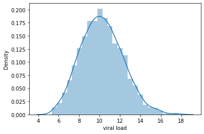

```python
sns.distplot(df['viral load'])
```

#### K-S Test

- **Null Hypothesis** ( $H_0):$ viral load of women with 0 Severity level , 1 Severity level, and 2 Severity level has same Distribution.
- **Alternative Hypothesis** ($H_a):$ viral load of women with 0 Severity level , 1 Severity level, and 2 Severity level has **Different Distribution** .

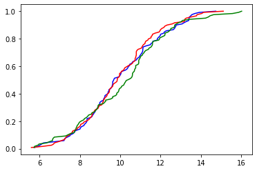

```python
from statsmodels.distributions.empirical_distribution import ECDF
e1 = ECDF(women_s_zero)
e2 = ECDF(women_s_one)
e3=ECDF(women_s_two)
plt.figure()
plt.plot(e1.x, e1.y, c='b')
plt.plot(e2.x, e2.y, c='r')
plt.plot(e3.x, e3.y, c='g')
```

- **Problem Statement** : Is the mean viral load of women with 0 Severity level , 1 Severity level, and 2 Severity level the same

#### Null and Alternative Hypothesis

- **Null Hypothesis** ( $H_0):$ Average viral load of women with 0 Severity level , 1 Severity level, and 2 Severity level the same .
- **Alternative Hypothesis** ($H_a):$ Average viral load of women with 0 Severity level , 1 Severity level, and 2 Severity level is not same.

```python
df_women=df[df['sex']=='female']
df_women.groupby(['severity level'])['viral load'].mean()
```

```
severity level
0    10.120727
1    10.017468
2    10.216807
3    10.145974
4    10.647273
5    10.206250
Name: viral load, dtype: float64
```

```python
women_s_zero=df[(df['sex']=='female')&(df['severity level']==0)]['viral load'].sample(119)
women_s_one=df[(df['sex']=='female')&(df['severity level']==1)]['viral load'].sample(119)
women_s_two=df[(df['sex']=='female')&(df['severity level']==2)]['viral load'].sample(119)
```

```python
p_value=stats.f_oneway(women_s_zero,women_s_one,women_s_two)[1]
if p_value > 0.05:
     print('Since p_value > 0.05 we fail to reject the null hypothesis.')
else:
     print('Since p_value < 0.05 we reject the null hypothesis.')
```

```
Since p_value > 0.05 we fail to reject the null hypothesis.
```

### Since p-value is greater then 0.05, we fail to reject the null hypothesis, mean viral load of women with 0 Severity level , 1 Severity level, and 2 Severity level the **same**